# Introduction to spatial data in R

Dr. Emily Burchfield

# Objectives

- Learn how `R` opens, stores, and organizes shapefiles.
- Learn how `R` handles projection.
- `dplyr` a shapefile.
- MAKE A MAP

# Pre-lab assignment

- If you are not yet familiar with GIS and spatial analysis, you should probably read [this overview](https://mgimond.github.io/Spatial/introGIS.html).
- The entire [Spatial Data Science with R](https://rspatial.org/) online textbook is *excellent.* You can start by reading the chapter on [vector data](http://rspatial.org/spatial/rst/3-vectordata.html). If you’re unfamiliar with projection, you should also look at the chapter on [projection](http://rspatial.org/spatial/rst/6-crs.html). Even if you’re familiar with projection, you may want to review this chapter as it addresses projection in `R`.

# Set up

Hooray! We’ve finally made it to my favorite type of data: spatial data! Well, actually nearly all of the data we’ve already played contains some sort of spatial information (country names, state names, etc…), it just did not contain the coordinate and projection information required to make maps and conduct spatial analyses. This tutorial will focus on giving you the tools required to import, project, and create spatial data. There are several packages used by the `R` community to bring spatial data into `R`. These are:

- `sp`
- `rgdal`
- `sf`
- Our friend the `tidyverse`

Make sure you have these packages installed and loaded on your machine.

```r
library(sp) # old school - don't really need this package, just loading for reference
library(sf)
library(spData) # a bonus package that has some cool shapefiles
library(ggspatial)  # if you want to boost your ggplot mapping skillz

# plus, as always:
library(tidyverse)
```

# Spatial *objects* in `R`

First, some history…

`sf` (**simple features**) is the new go-to package for spatial analysis in `R`, replacing the `sp` package of yore.[^1] `sf` is a descendant of the `sp` package, made by the same folks, and has good inter-operability with `sp`. You can look through the [`sf`](https://r-spatial.github.io/sf/articles/sf1.html) and [`sp`](https://cran.r-project.org/web/packages/sp/vignettes/intro_sp.pdf) documentation to get a sense of all the things you can do with these powerful packages. The team behind the `sp` package initially created a set of new data classes that integrate our best friend the `data.frame` with some friends who at times can be very difficult to hang out with: point, polygon, and raster. These new data classes include the following:

```r
getClass("Spatial")
```

```
## Class "Spatial" [package "sp"]
##
## Slots:
##
## Name:         bbox proj4string
## Class:      matrix         CRS
##
## Known Subclasses:
## Class "SpatialPoints", directly
## Class "SpatialMultiPoints", directly
## Class "SpatialGrid", directly
## Class "SpatialLines", directly
## Class "SpatialPolygons", directly
## Class "SpatialPointsDataFrame", by class "SpatialPoints", distance 2
## Class "SpatialPixels", by class "SpatialPoints", distance 2
## Class "SpatialMultiPointsDataFrame", by class "SpatialMultiPoints", distance 2
## Class "SpatialGridDataFrame", by class "SpatialGrid", distance 2
## Class "SpatialLinesDataFrame", by class "SpatialLines", distance 2
## Class "SpatialPixelsDataFrame", by class "SpatialPoints", distance 3
## Class "SpatialPolygonsDataFrame", by class "SpatialPolygons", distance 2
```

`sf` on the other hand has a single `sf` class that incorporates a special geometry column into a dataframe. This geometry column can include different types of spatial data (e.g. points, polygons, lines, or multiple types). This is convenient because all `sf` objects can basically be treated like `data.frames` (PARTY!).

In `sp` world, the sub-classes followed by `DataFrame` like `SpatialPointsDataFrame`, include additional attributes in the form of a `data.frame`. For example, if you have a `SpatialPolygon` object of US Census blocks, then this object would *only* include the spatial information required to plot the Census block polygons. With a `SpatialPolygonDataFrame`, you can store this spatial information *and* additional data such as population, race, and income associated with each polygon. This may seem trivial, but, as I’ll show you below, this makes for an incredibly powerful way to organize, visualize, and analyze spatial data. In this class, we’ll focus on using `sf` objects since this is quickly becoming the norm, but I wanted you to also know about `sf`’s cool grandma, `sp`.

Enough about the history of spatial packages in R… let’s open some shapefiles! If you’re like me, you have folders full of shapefiles. A single shapefile is often split into many files (e.g. `.cpg`, `.dbf`, `.prj`, etc.), the most important of which is the sacred `.SHP` file. To get all of this info into an organized spatial object in `R` is easy. As I mentioned before, you can use lots of packages to do this (`rgdal`, `sf`, and `sp` notably), but in this tutorial, we’ll focus on `sf`:

```r
states <- st_read("./data/states.shp")
```

Here, I use the `st_read()` function to open my `.shp` file. Note that this function *automatically* finds all of the ancillary files associated with our shapefile (`.dbf`, `.prj`, etc). If for some reason these files are missing or broken, `st_read()` will throw an error, so make sure your shapefile contains all necessary pieces prior to loading in `R`!

To make things easier, in this tutorial we’ll mostly use data from the `spData` package. It contains some generic shapefiles for use in `R`, already formatted in `sf` or `sp` format and easy to load. Check out the [full list here](https://cran.r-project.org/web/packages/spData/readme/README.html). Today, we’ll work with the `us_states` object:

```r
# make sure you've installed and loaded spData first!
data("us_states")
class(us_states)
```

```
## [1] "sf"         "data.frame"
```

Excellent. Note that this `us_states` object is listed as both a simple feature (`sf`) and as a `data.frame`. Let’s inspect our data:

```r
glimpse(us_states)
```

```
## Rows: 49
## Columns: 7
## $ GEOID        <chr> "01", "04", "08", "09", "12", "13", "16", "18", "20", ...
## $ NAME         <chr> "Alabama", "Arizona", "Colorado", "Connecticut", "Flor...
## $ REGION       <fct> South, West, West, Norteast, South, South, West, Midwe...
## $ AREA         [km^2] 133709.27 [km^2], 295281.25 [km^2], 269573.06 [km^2],...
## $ total_pop_10 <dbl> 4712651, 6246816, 4887061, 3545837, 18511620, 9468815,...
## $ total_pop_15 <dbl> 4830620, 6641928, 5278906, 3593222, 19645772, 10006693...
## $ geometry     <MULTIPOLYGON [°]> MULTIPOLYGON (((-88.20006 3..., MULTIPOLY...
```

Note that if you love `sp` (full disclosure, I still use `sp` from time to time), it’s really easy to coerce this back to a `sp` object.

```r
states_sp <- as_Spatial(us_states)
class(us_states)
```

```
## [1] "sf"         "data.frame"
```

But for now we’ll stick with `sf`. Let’s take a peak at the other info stored in our `states` object. We can also access information about the bounding box of the spatial object:

```r
st_bbox(us_states)
```

```
##       xmin       ymin       xmax       ymax
## -124.70415   24.55868  -66.98240   49.38436
```

We can also access projection information:

```r
st_crs(us_states)
```

```
## Coordinate Reference System:
##   User input: EPSG:4269
##   wkt:
## GEOGCS["NAD83",
##     DATUM["North_American_Datum_1983",
##         SPHEROID["GRS 1980",6378137,298.257222101,
##             AUTHORITY["EPSG","7019"]],
##         TOWGS84[0,0,0,0,0,0,0],
##         AUTHORITY["EPSG","6269"]],
##     PRIMEM["Greenwich",0,
##         AUTHORITY["EPSG","8901"]],
##     UNIT["degree",0.0174532925199433,
##         AUTHORITY["EPSG","9122"]],
##     AUTHORITY["EPSG","4269"]]
```

Finally, the moment we’ve all been waiting for… let’s plot this baby! For now, we will use base `R` to plot this object, but in a future class we’ll learn about more sophisticated mapping tools.

If you just run `plot(us_states)`, you’ll get several maps, one for each attribute in the `sf` object:

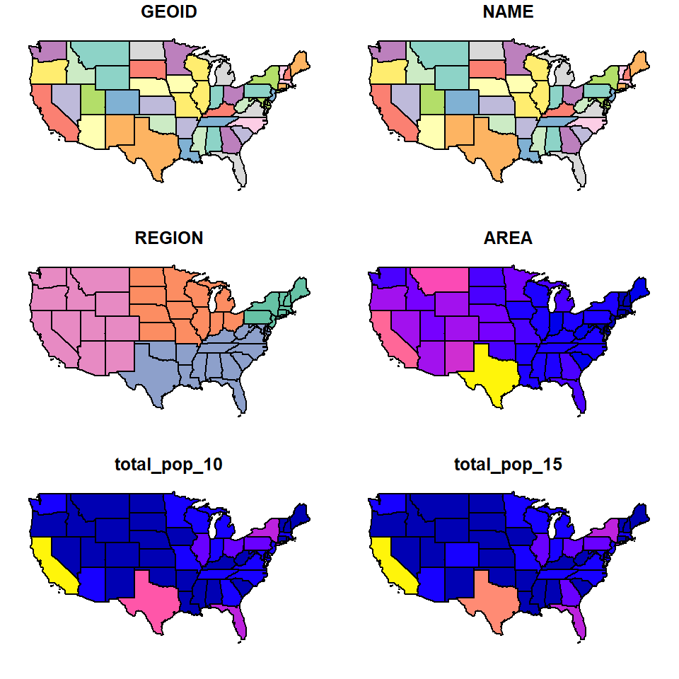

```r
plot(us_states)
```

To just plot the *geometry*, you use the `st_geometry()` function:

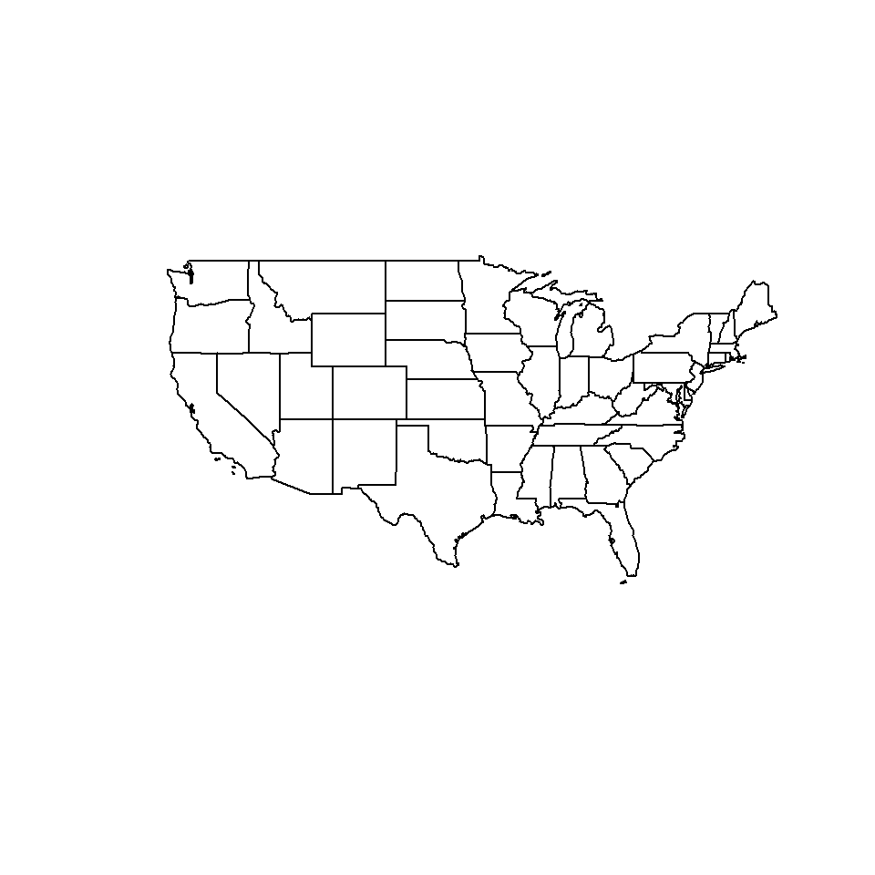

```r
plot(st_geometry(us_states))
```

And to plot only a single attribute, try this:

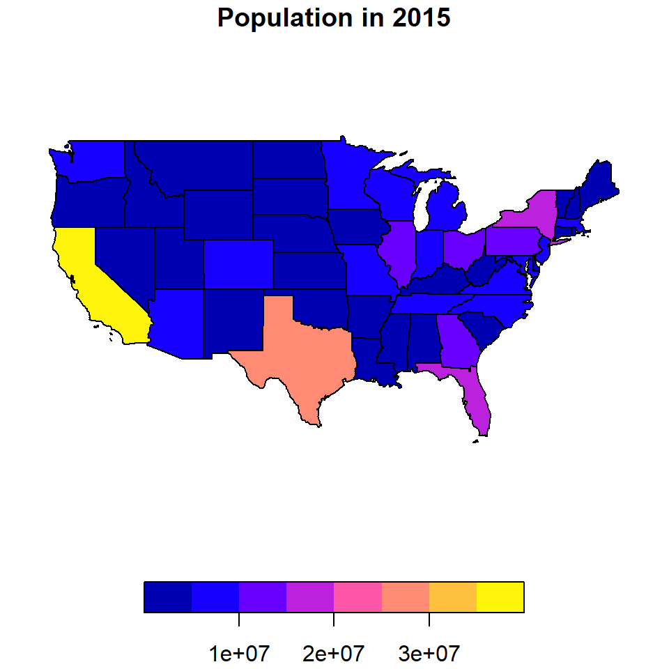

```r
plot(us_states["total_pop_15"], main = "Population in 2015")
```

# Projection

SO… what the heck is a projection?

Have you ever thought about how a map is *two*-dimensional but the world is, in fact, *three*-dimensional? Anytime we visualize our three-dimensional reality[^2] in two-dimensions, we have to *distort* (squish, stretch) the real shape of things so they can fit on a piece of paper or a screen. Maps are two-dimensional objects; the Earth is not. The way we portray [(pseudo-)](https://www.scientificamerican.com/article/earth-is-not-round/)spherical Earth on a flat surface is by using a *projection*. Each projection is associated with a particular coordinate system. A *coordinate system* is a way to locate everything on Earth’s surface in x and y space. There are a bazillion coordinate systems, and each coordination system comes with strong assumptions and distortions (and [fan-base](https://xkcd.com/977/)):

- Geographic Coordinate System (GCS): good ol’ latitude and longitude (degrees, minutes, seconds); we think of data in GCS as *unprojected* (if this doesn’t make sense to you, review the tutorial I’ve made exclusively on projection);
- Universal Transverse Mercator (UTM): lots of zones to choose from, Utah sits in `12N`;
- State Plane Coordinate System: some states have their own systems, i.e. North Carolina Coordinate System
- National systems: If working in another country, check out country-specific projections. Kandawala Sri Lanka Grid anyone?

Each coordinate system is tied to a *datum*. This is essentially a reference point, the starting point from which coordinates are measured (i.e. lat and lon are based on the equator and prime meridian). In `R` we can access the projection information for a `sf` object using the `st_crs()` function you saw above:

```r
st_crs(us_states)
```

```
## Coordinate Reference System:
##   User input: EPSG:4269
##   wkt:
## GEOGCS["NAD83",
##     DATUM["North_American_Datum_1983",
##         SPHEROID["GRS 1980",6378137,298.257222101,
##             AUTHORITY["EPSG","7019"]],
##         TOWGS84[0,0,0,0,0,0,0],
##         AUTHORITY["EPSG","6269"]],
##     PRIMEM["Greenwich",0,
##         AUTHORITY["EPSG","8901"]],
##     UNIT["degree",0.0174532925199433,
##         AUTHORITY["EPSG","9122"]],
##     AUTHORITY["EPSG","4269"]]
```

Excellent. Our data is currently in the NAD83 Geographic Coordinate System which plots locations on a sphere using longitude and latitude with the North American Datum (NAD) 1983 as a reference line (but does not project these coordinates into two-dimensional space). This is fine if we’re only interested in visualizing our data spatially, but if we have any plans to use the spatial data to compute distance or area, then we need to project our data (from 3D to 2D). This is fairly straightforward in `R`. Say we want to reproject this data into [USA Contiguous Albers Equal Area Conic](http://spatialreference.org/ref/esri/usa-contiguous-albers-equal-area-conic/):

```r
states <- st_transform(us_states, CRS("+proj=aea +lat_1=29.5 +lat_2=45.5 +lat_0=37.5 +lon_0=-96 +x_0=0 +y_0=0 +ellps=GRS80 +datum=NAD83 +units=m +no_defs"))
```

I got that crazy long string by searching for the projection on spatialreference.org and clicking the [Proj4](http://spatialreference.org/ref/esri/usa-contiguous-albers-equal-area-conic/proj4/) link. `R` expects projection information to come in this `proj4` format.

If you happen to have a shapefile that has an undefined projection in `R`, but you happen to know what projection the data is in, you can set the projection as follows:

```r
shp <- st_read("./path/to/shp.shp")
st_crs(shp) <- CRS("+proj=aea +lat_1=29.5 +lat_2=45.5 +lat_0=37.5 +lon_0=-96 +x_0=0 +y_0=0 +ellps=GRS80 +datum=NAD83 +units=m +no_defs")
```

People tend to hate projections[^3] and generally don’t understand them very well. It is, however, VERY important that you project your data correctly. If you fail to do this, it’s highly likely that your spatial analyses will be wrong. So let’s learn how this stuff works once and for all.

Finally, don’t forget that the map projection you use strongly impacts the way you visualize and analyze your data (see [here](https://source.opennews.org/articles/choosing-right-map-projection/) or [here](https://www.economist.com/blogs/dailychart/2010/11/cartography)).

# Creating a new shapefile in `R`

Let’s say I’m a volcanologist and I find a really cool data describing all eruptions on Earth during the Holocene.[^4] The data is stored in a `.csv` document. We now know how to open the `.csv` in `R` and inspect its contents:

```r
volcano <- read.csv('./data/volcano.csv')
glimpse(volcano)
```

```
## Rows: 1,496
## Columns: 13
## $ ï..Volcano.Number    <int> 210010, 210020, 210030, 210040, 211001, 211003...
## $ Volcano.Name         <chr> "West Eifel Volcanic Field", "Chaine des Puys"...
## $ Country              <chr> "Germany", "France", "Spain", "Spain", "Italy"...
## $ Primary.Volcano.Type <chr> "Maar(s)", "Lava dome(s)", "Pyroclastic cone(s...
## $ Activity.Evidence    <chr> "Eruption Dated", "Eruption Dated", "Evidence ...
## $ Last.Known.Eruption  <chr> "8300 BCE", "4040 BCE", "Unknown", "3600 BCE",...
## $ Region               <chr> "Mediterranean and Western Asia", "Mediterrane...
## $ Subregion            <chr> "Western Europe", "Western Europe", "Western E...
## $ Latitude             <dbl> 50.170, 45.775, 42.170, 38.870, 43.250, 42.600...
## $ Longitude            <dbl> 6.850, 2.970, 2.530, -4.020, 10.870, 11.930, 1...
## $ Elevation..m.        <int> 600, 1464, 893, 1117, 500, 800, 949, 458, 1281...
## $ Dominant.Rock.Type   <chr> "Foidite", "Basalt / Picro-Basalt", "Trachybas...
## $ Tectonic.Setting     <chr> "Rift zone / Continental crust (>25 km)", "Rif...
```

But we’re not here to learn how to work with `.csv` data… we have now graduated to spatial data! So how do we turn our `.csv` into a `sf` object?

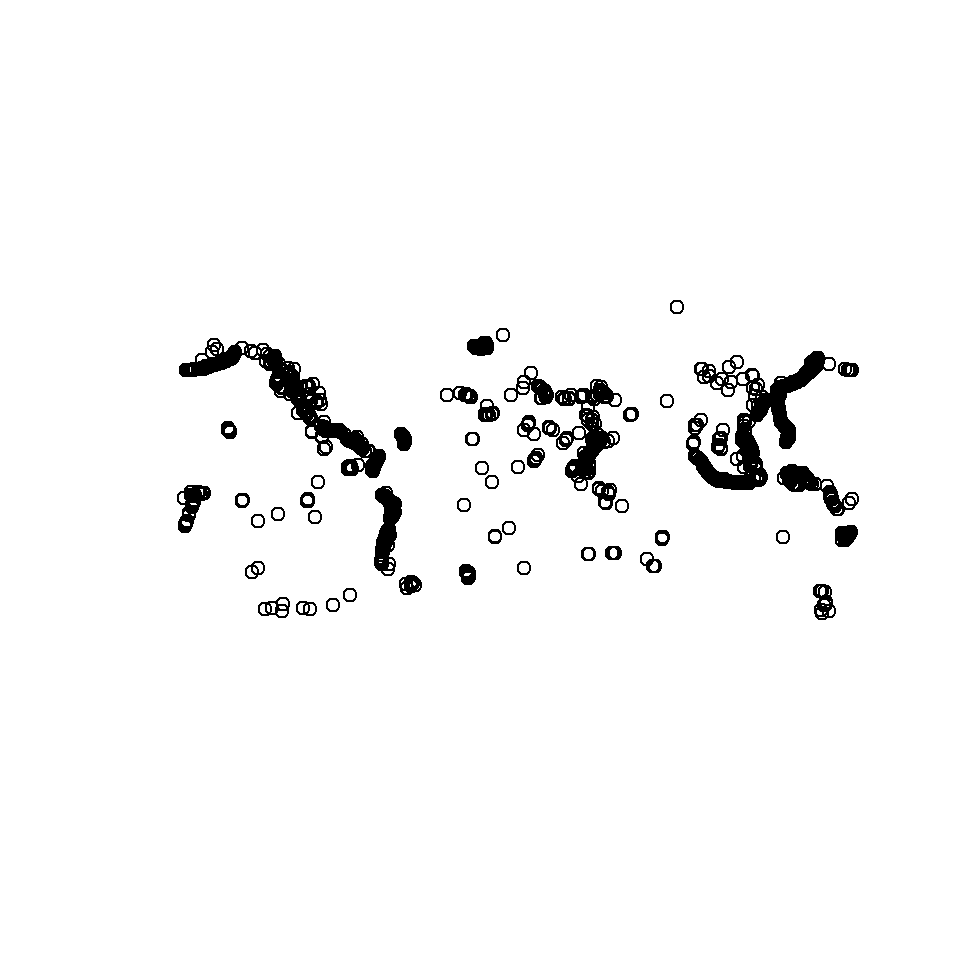

```r
volcano_sf <- st_as_sf(volcano, coords=c("Longitude", "Latitude"))
st_crs(volcano_sf) <- "+proj=longlat +ellps=WGS84 +datum=WGS84 +no_defs"
plot(st_geometry(volcano_sf))
```

What’s happening here? First, we feed the `st_as_sf()` function the two things it needs to turn this `.csv` into an `sf` object: data and coordinates. The latitude and longitude are stored in original `.csv`. Coordinates are always listed in format `x,y`, so take a second to think about why `longitude` is associated with `x` (vertical lines, moving along x-axis of a graph) and `latitude` with `y` (horizontal lines, moving along the y-axis of a graph).

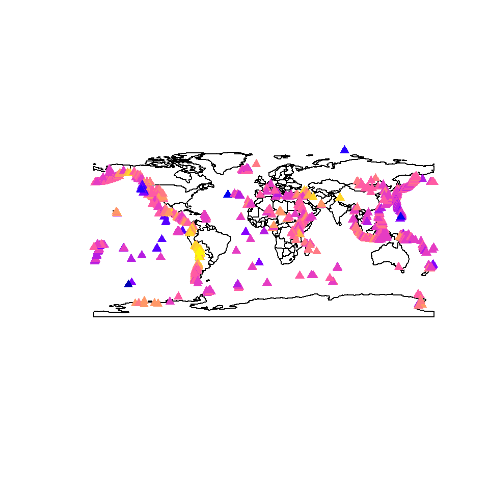

```r
data("world") # from spData
plot(st_geometry(world))
plot(volcano_sf["Elevation..m."], pch=17, main = "How high those 'canos", add=T) # all the dots from R reading in the csv poorly
```

We’ll learn how to use `ggplot` for `sf` plotting magic soon. For now, note how you can plot a single attribute by calling `plot(sf["attribute_name"])`. So in this plot, the *color* of the point represents the elevation of the volcano! The `pch` argument changes the shape of the points. I went with volcanic triangles, but there are [many other options](http://www.sthda.com/english/wiki/r-plot-pch-symbols-the-different-point-shapes-available-in-r). Also added a title using the `main` argument.

# Maps with `ggplot2`

Loading spatial data in R is cool, but spatial data becomes extremely *powerful* when you map it. Though it wasn’t originally designed for mapping, you can do quite a bit of mapping with our friend `ggplot2`. Check this out:

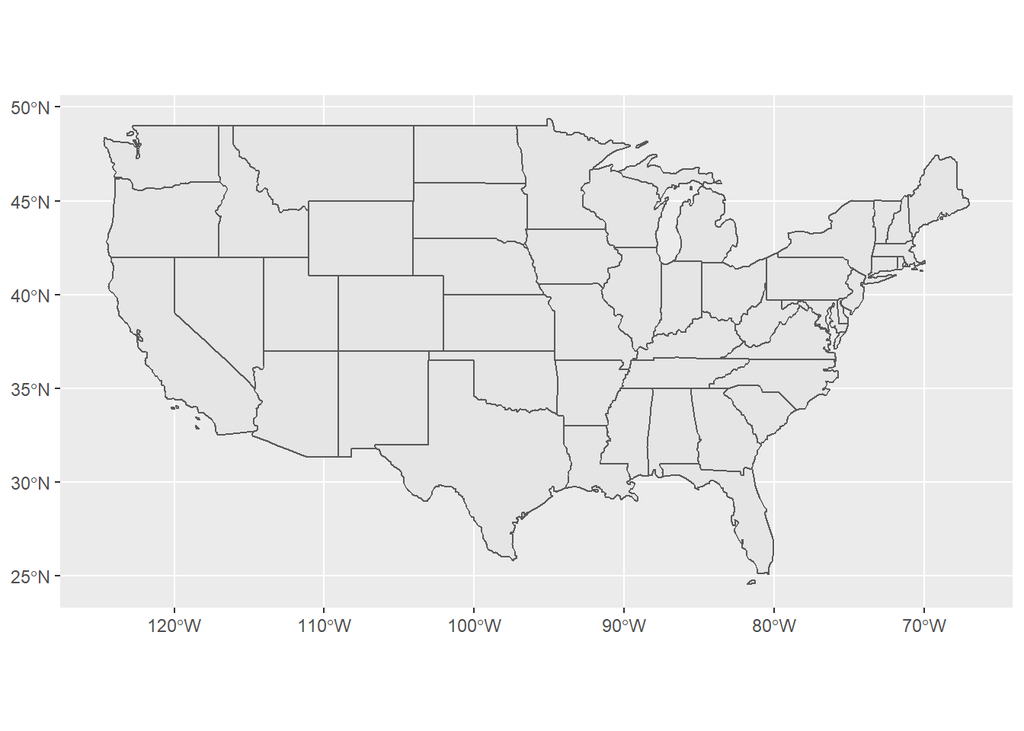

```r
ggplot() +
  geom_sf(data = us_states)
```

From there, you can do all of the usual ggplot tuning to make things look a bit better:

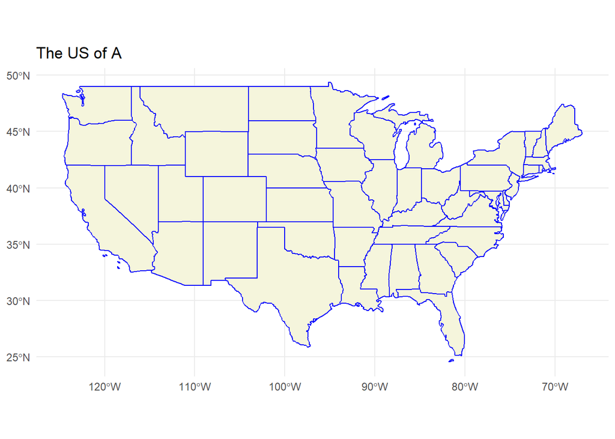

```r
ggplot() +
  geom_sf(data = us_states, color = "blue", fill = "beige") +
  labs(title = "The US of A") +
  theme_minimal()
```

What if we want to make a new map visualizing the total population in each major region in the US?

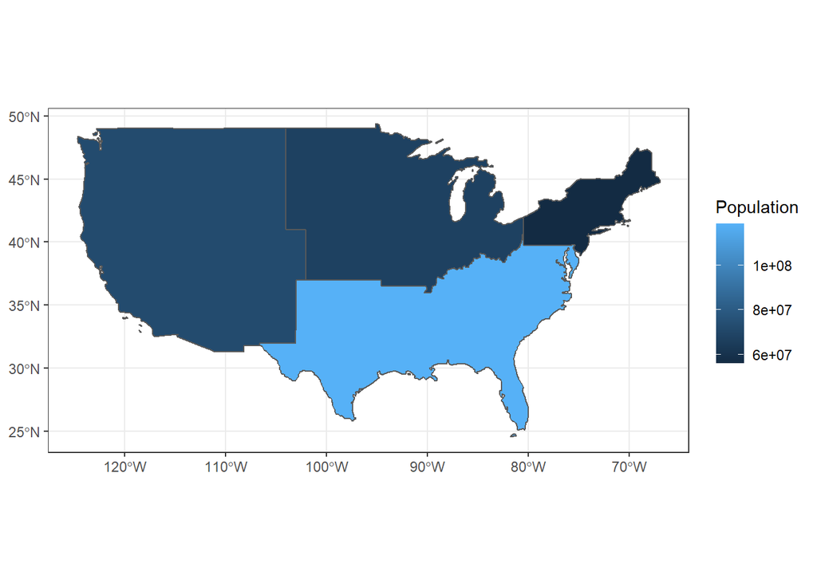

```r
us_states %>%
  group_by(REGION) %>%
  summarize(POP_TOTAL = sum(total_pop_15)) %>%
  ggplot() +
  geom_sf(aes(fill = POP_TOTAL)) +
  labs(fill = "Population") +
  theme_bw()
```

That’s right guys. I just piped a spatial object into a `ggplot` to make a map. One of the best things about the `sf` package is that it allows us to apply all of the amazing tools we’ve learned to date (hellooooo `tidyverse`) to wrangle and explore `data.frames` to spatial data.

[figure not shown]

So, say we want to highlight the fine state of Georgia. We could do something like this:

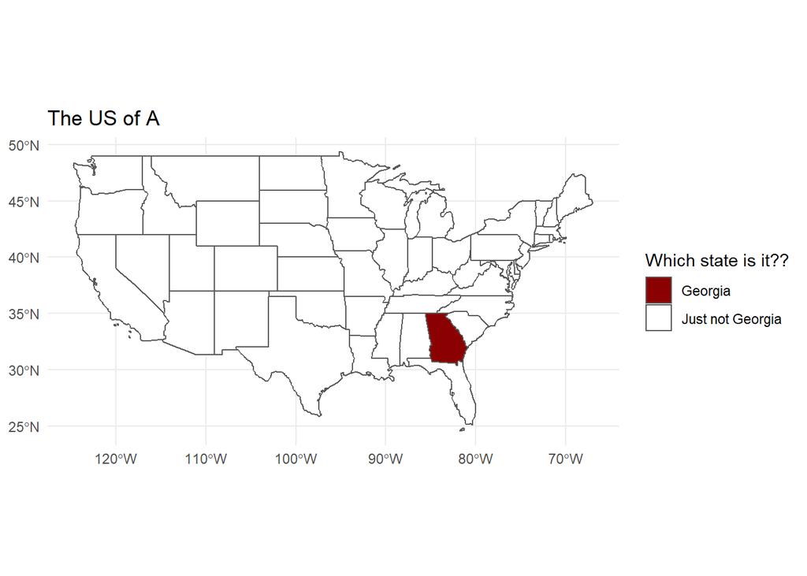

```r
us_states %>%
  mutate(IS_IT_GA = ifelse(NAME == "Georgia", "Georgia", "Just not Georgia")) %>%
  ggplot() +
  geom_sf(aes(fill = IS_IT_GA)) + # drop data = us_states; the data is now what you pipe into the plot
  # also, move the fill into the aes() b/c it applies differently to each shape
  labs(title = "The US of A",
       fill = "Which state is it??") +
  theme_minimal() +
  scale_fill_manual(values = c("dark red", "white"))
```

And say we have a new shapefile that shows the roads across the US? Then we’d simply add a new `geom_sf()` call to the map with this new shapefile, like so:

```r
ggplot() +
  geom_sf(data = us_states) +
  geom_sf(data = us_roads)
```

Note that to visualize multiple shapefiles on the same plot, they need to be in the same projection.

Finally, [this post](https://www.r-spatial.org/r/2018/10/25/ggplot2-sf.html) has some other useful tricks including using the `ggspatial` package to add a scale bar and compass:

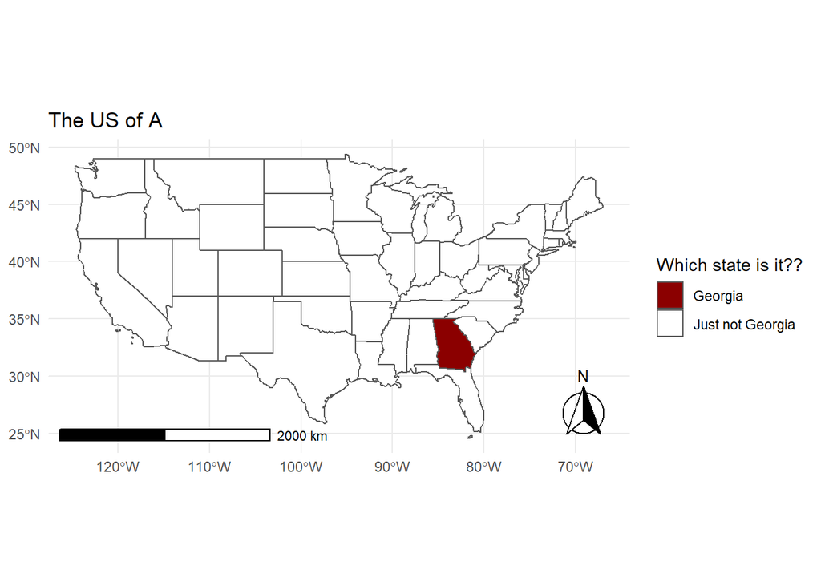

```r
library(ggspatial)
us_states %>%
  mutate(IS_IT_GA = ifelse(NAME == "Georgia", "Georgia", "Just not Georgia")) %>%
  ggplot() +
  geom_sf(aes(fill = IS_IT_GA)) +
  labs(title = "The US of A",
       fill = "Which state is it??") +
  theme_minimal() +
  scale_fill_manual(values = c("dark red", "white")) +
  annotation_scale(location = "bl", width_hint = 0.5) +
  annotation_north_arrow(location = "br", which_north = "true",
                         style = north_arrow_fancy_orienteering())
```

There are *many* things we can do with spatial data I haven’t mentioned here. One of the most useful is linking multiple spatial datasets so they can “talk” to one another. You can do this by extracting information from one dataset to another (so, for example, extracting to points values of a shapefile or raster) or by merging data spatially or using columns in the dataset. We’ll talk more about extraction when we talk about rasters. To merge, check out the base `R` `merge()` function, which works like this:

```r
shp1 <- st_read("./data/shp1.shp")
shp2 <- st_read("./data/shp2.shp")

# assume both shapefiles represent US states and have a column that lists the abbreviation for each state called ST_ABBR
# we can then do a merge like this!
shp_final <- merge(shp1, shp1, by = "ST_ABBR", all = T)
```

# Advanced mapping tools

…that we won’t cover, but that are *very* cool and that I encourage you to explore:

- Shiny overview [here](https://shiny.rstudio.com/tutorial/).
- Leaflet example found [here](https://sesync-ci.github.io/maps-in-R-lesson/2016/09/14/) and tutorials [here](https://rstudio.github.io/leaflet/) and [here](https://bhaskarvk.github.io/user2017.geodataviz/).

# Additional Resources

- Chapter 2 of *Applied Spatial Data Analysis with R* (reference on Canvas More Resources page). The authors of the book are also the authors of the `sp` package.
- This [tutorial](http://data-analytics.net/cep/Schedule_files/geospatial.html) created by David Beskow.
- DataCamp’s [Working with Geospatial Data in R](https://www.datacamp.com/courses/working-with-geospatial-data-in-r) tutorial created by Charlotte Wickham (I believe she’s the sister of Hadley Wickham of tidyverse family, pretty prolific family!).
- More information on [opening spatial data in R](http://neondataskills.org/R/open-shapefiles-in-R/)
- For more on projection in R, see [this tutorial](http://neondataskills.org/R/vector-data-reproject-crs-R/).
- For more on transforming csv files into shapefiles, see [this tutorial](http://neondataskills.org/R/csv-to-shapefile-R/)
- As I was building this tutorial, I really enjoyed this [overview of mapping with `ggplot2`](http://eriqande.github.io/rep-res-web/lectures/making-maps-with-R.html)
- [This tutorial](http://www.molecularecologist.com/2012/09/making-maps-with-r/) goes much further than I did with the `maps` package.
- Tons of maps you can make with base `R` and `spplot()` can be found [here](http://rspatial.r-forge.r-project.org/gallery/).
- Sometimes it’s very useful to visualize space-time dynamics with animations. A short intro can be found [here](http://www.maths.lancs.ac.uk/~rowlings/Teaching/UseR2012/crime.html).
- [Great set of slides](http://von-tijn.nl/tijn/research/presentations/tmap_user2015.pdf) reviewing `tmap` capabilities.
- I also really like [this overview](https://cran.r-project.org/doc/contrib/intro-spatial-rl.pdf) of mapping in `R`.
[^1]: I’ve got a whole tutorial on how to work with this package [here](https://eburchfield.github.io/files/5_spatial_intro_lab.html) for those who are interested!
[^2]: Ok, ok, I’m not getting into [the dimensionality of reality](https://www.youtube.com/watch?v=lM_HPAXwJFw), but you get the idea
[^3]: The only person who was ever pumped about projections was an old Flemish dude named [Mercator.](https://en.wikipedia.org/wiki/Gerardus_Mercator)
[^4]: Volcanologists rejoice! This data exists and I encourage you to use it!